# Predicting Natural gas prices using ML

## Predicting Natural Gas Prices in the Canadian Energy Sector Using Machine Learning

### Problem Statement

Natural gas holds a position of strategic importance in the Canadian energy sector. Therefore, understanding and predicting natural gas prices is crucial for both natural gas producers and consumers. The purpose of this project is to utilize machine learning (ML) techniques to predict natural gas prices providing insights, for decision making in the energy sector.

To achieve this goal I utilized a real world dataset that contains information on energy commodity prices such as 'Home_Heating_Oil', 'Diesel','Propane','Gasoline', 'Household_heating_fuel', 'Diesel_fuel','unleaded_gasoline', 'Closing_inventory', 'Heating_Degree_Days'. The dataset, was obtained from the website of the Canadian Natural Gas Association[https://www.cga.ca/natural-gas-statistics/]

The primary objective of this project is to develop a model capable of accurately forecasting natural gas prices using energy commodity prices.

Not only will this project contribute to the field of energy economics but to showcase how data science and machine learning can be practically applied to address real world challenges.

### How to Approach this Machine Learning Problem

1. Explore the data and find correlations between inputs and targets
2. Pick the right model, loss functions and optimizer for the problem at hand
3. Scale numeric variables and one-hot encoding of categorical variables
4. Set aside a test set (using a fraction of the training set)
5. Train the model
6. Make predictions on the test set and compute the loss
7. Optimize the model using the hyperparameter tuning

### Loading the Dataset

```python
import pandas as pd

df_prices = pd.read_csv("prices.csv", low_memory=False, parse_dates=['Date'])
```

```python
df_prices.head()
```

|  | Date | Natural_gas | Propane | Home_Heating_Oil | Diesel | Gasoline | Household_heating_fuel | Diesel_fuel | unleaded_gasoline | propane_prices | Closing_inventory | Heating_Degree_Days | Season |
| --- | --- | --- | --- | --- | --- | --- | --- | --- | --- | --- | --- | --- | --- |
| 0 | 2016-01-01 | 2.3324 | 22.013318 | 24.661104 | 24.568578 | 26.716676 | 90.555574 | 95.031260 | 92.6 | 56.2 | 22220402.0 | 702.242466 | Winter |
| 1 | 2016-02-01 | 2.0374 | 22.091657 | 23.764433 | 23.605381 | 25.014426 | 87.262998 | 91.305615 | 86.7 | 56.4 | 20472652.0 | 588.586307 | Winter |
| 2 | 2016-03-01 | 1.5752 | 22.561692 | 24.155181 | 23.874215 | 26.514714 | 88.697823 | 92.345465 | 91.9 | 57.6 | 21006679.0 | 492.604649 | Spring |
| 3 | 2016-04-01 | 1.3116 | 22.875049 | 23.959156 | 23.664283 | 28.851702 | 87.978019 | 91.533448 | 100.0 | 58.4 | 21036483.0 | 404.229018 | Spring |
| 4 | 2016-05-01 | 1.1448 | 22.600862 | 24.585031 | 24.560238 | 30.034622 | 90.276232 | 94.999000 | 104.1 | 57.7 | 22392448.0 | 155.397441 | Spring |

Check the data type for each column

```python
df_prices.info()
```

```
<class 'pandas.core.frame.DataFrame'>
RangeIndex: 88 entries, 0 to 87
Data columns (total 13 columns):
 #   Column                  Non-Null Count  Dtype
---  ------                  --------------  -----
 0   Date                    84 non-null     datetime64[ns]
 1   Natural_gas             84 non-null     float64
 2   Propane                 84 non-null     float64
 3   Home_Heating_Oil        84 non-null     float64
 4   Diesel                  84 non-null     float64
 5   Gasoline                84 non-null     float64
 6   Household_heating_fuel  84 non-null     float64
 7   Diesel_fuel             84 non-null     float64
 8   unleaded_gasoline       84 non-null     float64
 9   propane_prices          84 non-null     float64
 10  Closing_inventory       84 non-null     float64
 11  Heating_Degree_Days     84 non-null     float64
 12  Season                  84 non-null     object
dtypes: datetime64[ns](1), float64(11), object(1)
memory usage: 9.1+ KB
```

Checking for missing values in each column of the dataset.

```python
df_prices.isnull().sum()
```

```
Date                      4
Natural_gas               4
Propane                   4
Home_Heating_Oil          4
Diesel                    4
Gasoline                  4
Household_heating_fuel    4
Diesel_fuel               4
unleaded_gasoline         4
propane_prices            4
Closing_inventory         4
Heating_Degree_Days       4
Season                    4
dtype: int64
```

Calculating the percentage of missing values in each column of the dataset.

```python
df_prices.isnull().sum()/df_prices.shape[0]*100
```

```
Date                      4.545455
Natural_gas               4.545455
Propane                   4.545455
Home_Heating_Oil          4.545455
Diesel                    4.545455
Gasoline                  4.545455
Household_heating_fuel    4.545455
Diesel_fuel               4.545455
unleaded_gasoline         4.545455
propane_prices            4.545455
Closing_inventory         4.545455
Heating_Degree_Days       4.545455
Season                    4.545455
dtype: float64
```

Drop rows with missing values

```python
df=df_prices.dropna()
```

```python
df.shape
```

```
(84, 13)
```

```python
df.isnull().sum()
```

```
Date                      0
Natural_gas               0
Propane                   0
Home_Heating_Oil          0
Diesel                    0
Gasoline                  0
Household_heating_fuel    0
Diesel_fuel               0
unleaded_gasoline         0
propane_prices            0
Closing_inventory         0
Heating_Degree_Days       0
Season                    0
dtype: int64
```

```python
# Finding duplicates across all columns
duplicates = df[df.duplicated()]
print(duplicates)
```

```
Empty DataFrame
Columns: [Date, Natural_gas, Propane, Home_Heating_Oil, Diesel, Gasoline, Household_heating_fuel, Diesel_fuel, unleaded_gasoline, propane_prices, Closing_inventory, Heating_Degree_Days, Season]
Index: []
```

# Exploratory Data Analysis

Statistics of the numerical columns

```python
df.describe()
```

|  | Natural_gas | Propane | Home_Heating_Oil | Diesel | Gasoline | Household_heating_fuel | Diesel_fuel | unleaded_gasoline | propane_prices | Closing_inventory | Heating_Degree_Days |
| --- | --- | --- | --- | --- | --- | --- | --- | --- | --- | --- | --- |
| count | 84.000000 | 84.000000 | 84.000000 | 84.000000 | 84.000000 | 84.000000 | 84.000000 | 84.000000 | 84.000000 | 8.400000e+01 | 84.000000 |
| mean | 2.561685 | 34.313040 | 34.441915 | 32.921815 | 35.434012 | 126.470710 | 127.341581 | 122.814286 | 87.601190 | 2.063073e+07 | 331.389913 |
| std | 1.337081 | 7.763523 | 9.779571 | 8.603675 | 7.168506 | 35.910585 | 33.279015 | 24.846042 | 19.820274 | 4.315099e+06 | 259.167583 |
| min | 0.740500 | 22.013318 | 23.764433 | 23.311091 | 22.446624 | 87.262998 | 90.167300 | 77.800000 | 56.200000 | 1.100469e+07 | 6.021753 |
| 25% | 1.754125 | 31.864473 | 27.903201 | 27.158461 | 30.409694 | 102.460554 | 105.048925 | 105.400000 | 81.350000 | 1.742016e+07 | 65.921709 |
| 50% | 2.201000 | 34.860948 | 32.855069 | 31.390418 | 33.727640 | 120.643814 | 121.418136 | 116.900000 | 89.000000 | 2.108170e+07 | 310.602630 |
| 75% | 2.998875 | 35.193890 | 34.868195 | 33.774953 | 38.401616 | 128.036012 | 130.641518 | 133.100000 | 89.850000 | 2.403753e+07 | 584.352606 |
| max | 6.860200 | 50.176263 | 64.911546 | 58.077727 | 59.780727 | 238.355198 | 224.644649 | 207.200000 | 128.100000 | 2.825048e+07 | 796.012212 |

```python
!pip install plotly matplotlib seaborn --quiet
```

```python
import plotly.express as px
import matplotlib
import matplotlib.pyplot as plt
import seaborn as sns
%matplotlib inline
```

### Visualize the distributions of the numeric columns

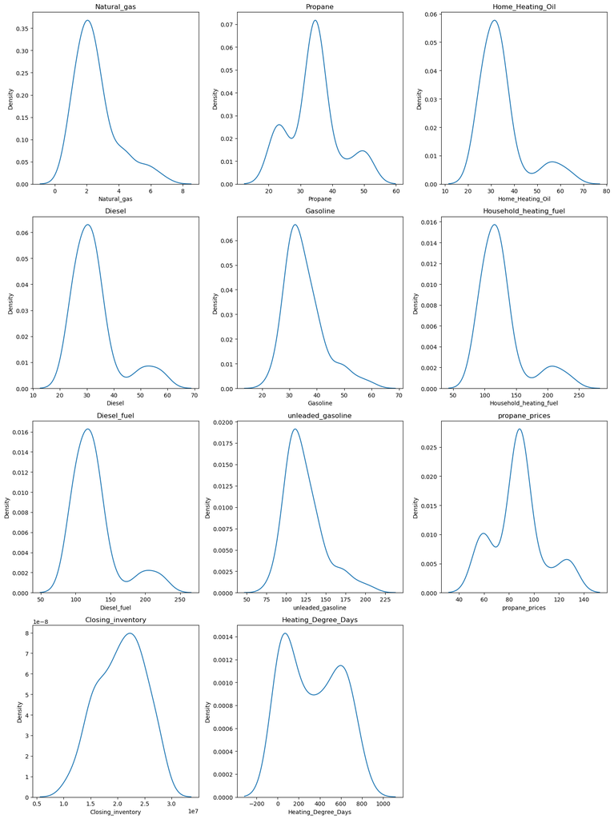

```python
import seaborn as sns
import matplotlib.pyplot as plt
import warnings
warnings.filterwarnings("ignore")

# Selecting numeric columns from df
numeric_columns = df.select_dtypes(include="number").columns

# Determine the number of rows/columns for the subplot grid
n_cols = 3  # You can adjust this as needed
n_rows = (len(numeric_columns) + n_cols - 1) // n_cols

# Create a figure and a set of subplots
plt.figure(figsize=(15, 5 * n_rows))

# Enumerate through numeric columns and create KDE plots
for idx, col in enumerate(numeric_columns):
    plt.subplot(n_rows, n_cols, idx + 1)
    sns.kdeplot(data=df, x=col)
    plt.title(col)

# Ensure the layout is not too cramped
plt.tight_layout()
plt.show()
```

boxplot to identify outliers

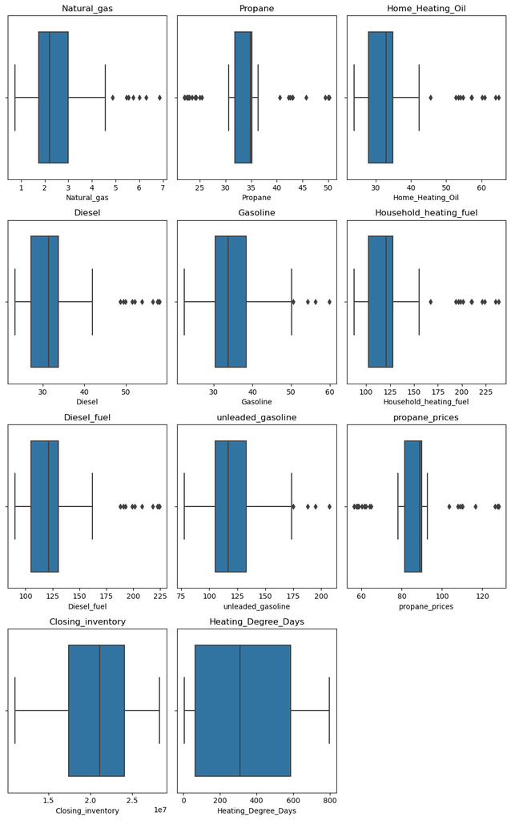

```python
# Selecting numeric columns from df_clean
numeric_columns = df.select_dtypes(include="number").columns

# Determine the number of rows/columns for the subplot grid
n_cols = 3
n_rows = (len(numeric_columns) + n_cols - 1) // n_cols

# Create a figure and a set of subplots
plt.figure(figsize=(10, 4 * n_rows))

# Enumerate through numeric columns and create boxplots
for idx, col in enumerate(numeric_columns):
    plt.subplot(n_rows, n_cols, idx + 1)
    sns.boxplot(data=df, x=col)
    plt.title(col)

# Ensure the layout is not too cramped
plt.tight_layout()
plt.show()
```

Some of the columns have outliers

scatter plots to understand relationships

[figure not shown]

```python
import seaborn as sns
import matplotlib.pyplot as plt

variables = ['Propane', 'Home_Heating_Oil', 'Diesel',
             'Gasoline', 'Household_heating_fuel', 'Diesel_fuel',
             'unleaded_gasoline', 'Closing_inventory',
             'Heating_Degree_Days']

n_cols = 3
n_rows = (len(variables) + n_cols - 1) // n_cols

plt.figure(figsize=(15, 5 * n_rows))

for idx, var in enumerate(variables):
    if var in df.columns:
        plt.subplot(n_rows, n_cols, idx + 1)
        sns.scatterplot(data=df, x=var, y='Natural_gas')
        plt.title(var)
    else:
        print(f"Column {var} not found in DataFrame.")

plt.tight_layout()
plt.show()
```

Correlation with heatmap to interpret relation and multicorlinearity

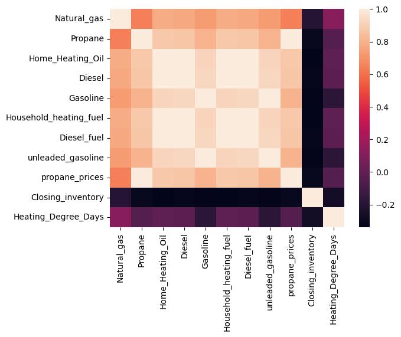

```python
s=df.select_dtypes(include="number").corr()
sns.heatmap(s, annot=False)
plt.figure(figsize=(20, 20))
```

```python
df.corr()
```

|  | Natural_gas | Propane | Home_Heating_Oil | Diesel | Gasoline | Household_heating_fuel | Diesel_fuel | unleaded_gasoline | propane_prices | Closing_inventory | Heating_Degree_Days |
| --- | --- | --- | --- | --- | --- | --- | --- | --- | --- | --- | --- |
| Natural_gas | 1.000000 | 0.642015 | 0.783828 | 0.773212 | 0.729466 | 0.783828 | 0.773212 | 0.729466 | 0.642015 | -0.203935 | 0.116264 |
| Propane | 0.642015 | 1.000000 | 0.875974 | 0.866069 | 0.804076 | 0.875974 | 0.866069 | 0.804076 | 1.000000 | -0.312201 | -0.045625 |
| Home_Heating_Oil | 0.783828 | 0.875974 | 1.000000 | 0.996511 | 0.920300 | 1.000000 | 0.996511 | 0.920300 | 0.875974 | -0.338826 | -0.010300 |
| Diesel | 0.773212 | 0.866069 | 0.996511 | 1.000000 | 0.929941 | 0.996511 | 1.000000 | 0.929941 | 0.866069 | -0.318496 | -0.016508 |
| Gasoline | 0.729466 | 0.804076 | 0.920300 | 0.929941 | 1.000000 | 0.920300 | 0.929941 | 1.000000 | 0.804076 | -0.333362 | -0.184346 |
| Household_heating_fuel | 0.783828 | 0.875974 | 1.000000 | 0.996511 | 0.920300 | 1.000000 | 0.996511 | 0.920300 | 0.875974 | -0.338826 | -0.010300 |
| Diesel_fuel | 0.773212 | 0.866069 | 0.996511 | 1.000000 | 0.929941 | 0.996511 | 1.000000 | 0.929941 | 0.866069 | -0.318496 | -0.016508 |
| unleaded_gasoline | 0.729466 | 0.804076 | 0.920300 | 0.929941 | 1.000000 | 0.920300 | 0.929941 | 1.000000 | 0.804076 | -0.333362 | -0.184346 |
| propane_prices | 0.642015 | 1.000000 | 0.875974 | 0.866069 | 0.804076 | 0.875974 | 0.866069 | 0.804076 | 1.000000 | -0.312201 | -0.045625 |
| Closing_inventory | -0.203935 | -0.312201 | -0.338826 | -0.318496 | -0.333362 | -0.338826 | -0.318496 | -0.333362 | -0.312201 | 1.000000 | -0.275413 |
| Heating_Degree_Days | 0.116264 | -0.045625 | -0.010300 | -0.016508 | -0.184346 | -0.010300 | -0.016508 | -0.184346 | -0.045625 | -0.275413 | 1.000000 |

Treating Outliers

```python
# Function to remove outliers from DataFrame
def remove_outliers(df):
    Q1 = df.select_dtypes(include=['number']).quantile(0.25)

    Q3 = df.select_dtypes(include=['number']).quantile(0.75)
    IQR = Q3 - Q1
    return df[~((df < (Q1 - 1.5 * IQR)) |(df > (Q3 + 1.5 * IQR))).any(axis=1)]

# Apply the function
df = remove_outliers(df.select_dtypes(include=['number']))
```

Check for outliers

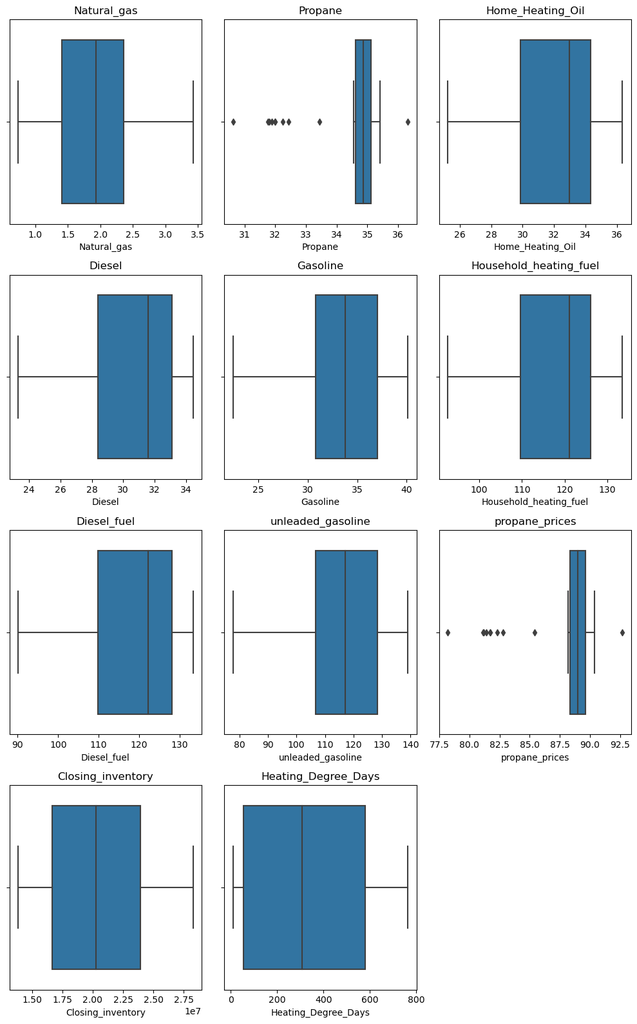

```python
import seaborn as sns
import matplotlib.pyplot as plt

# Selecting numeric columns from df_clean
numeric_columns = df.select_dtypes(include="number").columns

# Determine the number of rows/columns for the subplot grid
n_cols = 3
n_rows = (len(numeric_columns) + n_cols - 1) // n_cols

# Create a figure and a set of subplots
plt.figure(figsize=(10, 4 * n_rows))

# Enumerate through numeric columns and create boxplots
for idx, col in enumerate(numeric_columns):
    plt.subplot(n_rows, n_cols, idx + 1)
    sns.boxplot(data=df, x=col)
    plt.title(col)

# Ensure the layout is not too cramped
plt.tight_layout()
plt.show()
```

### Linear Regression Algorithm

```python
!pip install scikit-learn --quiet
```

```python
from sklearn import preprocessing
from sklearn.linear_model import LinearRegression
from sklearn.metrics import mean_squared_error
from sklearn.model_selection import train_test_split
from sklearn.metrics import r2_score
import numpy as np
from sklearn.preprocessing import StandardScaler
```

```python
numeric_cols = ['Home_Heating_Oil', 'Diesel','Propane',
       'Gasoline', 'Household_heating_fuel', 'Diesel_fuel',
       'unleaded_gasoline', 'Closing_inventory', 'Heating_Degree_Days']
scaler = StandardScaler()
scaler.fit(df[numeric_cols])
```

```
StandardScaler()
```

```python
scaled_inputs = scaler.transform(df[numeric_cols])
```

```python
#Create inputs and targets
scaled_inputs = ['Home_Heating_Oil', 'Diesel','Propane',
       'Gasoline', 'Household_heating_fuel', 'Diesel_fuel',
       'unleaded_gasoline', 'Closing_inventory', 'Heating_Degree_Days']
inputs, targets = df[scaled_inputs], df['Natural_gas']
```

Split the data into test and train

```python
inputs_train, inputs_test, targets_train, targets_test = train_test_split(inputs, targets, test_size=0.2)
```

```python
# Create and train the model
model = LinearRegression().fit(inputs_train, targets_train)

# Generate predictions
predictions_test = model.predict(inputs_test)

# Compute loss to evalute the model
r2 = r2_score(targets_test, predictions_test)
loss = np.sqrt(mean_squared_error(targets_test, predictions_test))
print(f'Test Loss: {loss:.2f}')
```

```
Test Loss: 0.58
```

The Loss of 0.58 indicates an average deviation of the model's predictions from the actual values.

### Random Forest Algorithm

```python
from sklearn.model_selection import train_test_split
from sklearn.ensemble import RandomForestRegressor
from sklearn.metrics import mean_squared_error, r2_score
```

```python
inputs_train, inputs_test, targets_train, targets_test = train_test_split(inputs, targets, test_size=0.2)
# Initialize the Random Forest Regressor
random_forest_model = RandomForestRegressor(random_state=0)

# Train the model
random_forest_model.fit(inputs_train, targets_train)

# Make predictions on the test set
targets_pred = random_forest_model.predict(inputs_test)

# Evaluate the model
Loss=np.sqrt(mean_squared_error(targets_test, targets_pred))
r2 = r2_score(targets_test, targets_pred)

print(f"{loss:.2f}, {r2:.2f}")
```

```
0.58, 0.60
```

```python
from sklearn.model_selection import GridSearchCV

# Define the parameter grid
param_grid = {
    'n_estimators': [100, 200, 300],
    'max_depth': [10, 20, 30],
    'min_samples_split': [2, 5, 10],
    'min_samples_leaf': [1, 2, 4],
    'max_features': ['auto', 'sqrt']
}

# Initialize the Grid Search model
grid_search = GridSearchCV(estimator=random_forest_model, param_grid=param_grid,
                           cv=3, n_jobs=-1, verbose=2, scoring='neg_mean_squared_error')

# Fit the grid search to the data
grid_search.fit(inputs_train, targets_train)

# Best parameters
best_params = grid_search.best_params_
print("Best Parameters:", best_params)

# Train the model with the best parameters
random_forest_model_optimized = RandomForestRegressor(**best_params, random_state=0)
random_forest_model_optimized.fit(inputs_train, targets_train)

# Make predictions and evaluate
targets_pred_optimized = random_forest_model_optimized.predict(inputs_test)
Loss_optimized = np.sqrt(mean_squared_error(targets_test, targets_pred_optimized))
r2_optimized = r2_score(targets_test, targets_pred_optimized)

print(f"Optimized Loss: {Loss_optimized:.2f}, Optimized R2: {r2_optimized:.2f}")
```

```
Fitting 3 folds for each of 162 candidates, totalling 486 fits
Best Parameters: {'max_depth': 10, 'max_features': 'sqrt', 'min_samples_leaf': 2, 'min_samples_split': 2, 'n_estimators': 100}
Optimized Loss: 0.44, Optimized R2: 0.46
```